# Governance: Data Protection

09 November 2021

## Learning Outcomes:

- Awareness of legislation affecting compliant collection, use and storage of personal data.
- Awareness of implications upon our day to day work.
- Consideration of potential sanctions set out in legislation.

## The Role of the ICO

- The Information Commissioner’s Office is charged with the responsibility of upholding information rights in the public interest.
- ICO is an independent regulatory office, reporting directly to parliament.
- Investigatory and enforcement powers.
- Point of contact for the public to report concerns.
- Outreach work, helping gov departments to compliantly share data.

## DPA Brief Overview

[**D**ata **P**rotection **A**ct](https://www.gov.uk/data-protection)  
Established many data access rights and responsibilities, such as:

- Subject Access Requests
- Legal framework for protected characteristics
- rights to access, erasure and correction

## GDPR Brief Overview

[**G**eneral **D**ata **P**rotection **R**egulation](https://ico.org.uk/for-organisations/guide-to-data-protection/guide-to-the-general-data-protection-regulation-gdpr/)  
Updated many of the terms set out in the DPA and added additional guidance:

- Setting out rights for minors
- Fair usage warnings
- Explaining AI-derived decisions
- Limitations to extent of collection and purpose, retention
- Responsibilities of data controllers, processors, DPOs, ICO
- Increased fines & sentences for non-compliance

## Task

Within your assigned groups, research the **DPA** or **GDPR**. You may use information from the websites provided and from the guest speaker if one has been used. Work as a team to complete all areas of the table on the next slide.

You will then be asked to present back to your colleagues. You can then use these presentations to complete the table for the legislation that you were not asked to present upon.

## DPA & GDPR

Navigate to the links in the previous slides. Use the information provided at these sites to populate the table below:

|  | **DPA** | **GDPR** |
| --- | --- | --- |
| Summary |  |  |
| Date Updated |  |  |
| Legal Requirements |  |  |
| Individual Rights |  |  |
| Penalties / Fines |  |  |

## Information & Asset Register (IAR)

In 2008, following 2 high-profile data loss incidents, the **Data Handling Procedures in Government review** was published. This required **all government departments** to **maintain a register of information assets**.

Note that this register should include pertinent metadata and risk assessments of all data, including open data and personal information accessible in any format, including information held in external systems.

If data processing results in a change to the schema of a registered asset, then a new entry should be created.

## IAR roles

The Security Policy Framework requires that government organisations should appoint and train Information Asset Owners for each of their information assets. Their role is to protect and manage information and to ensure that its value to the organisation is fully exploited.

## IAR roles (2)

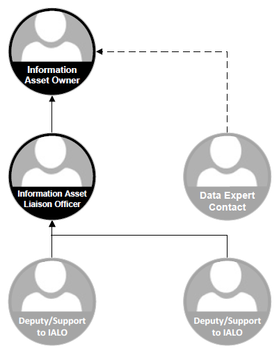

## IAR roles (3)

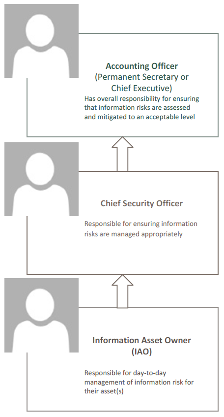

## Open Data

“Open data is data that can be freely used, re-used and redistributed by anyone - subject only, at most, to the requirement to attribute and sharealike.” [Open Data Handbook accessed, 09/11/21](https://opendatahandbook.org/guide/en/what-is-open-data/)

## Personal Data

“Personal data is information that relates to an identified or identifiable individual. What identifies an individual could be as simple as a name or a number or could include other identifiers such as… a cookie identifier, or other factors.”

“If you cannot directly identify an individual from that information, then you need to consider whether the individual is still identifiable. You should take into account the information you are processing together with all the means reasonably likely to be used by either you or any other person to identify that individual.”

“Information which has had identifiers removed or replaced in order to pseudonymise the data is still personal data for the purposes of UK GDPR.” [ICO - what is personal data, accessed 09/11/21](https://ico.org.uk/for-organisations/guide-to-data-protection/guide-to-the-general-data-protection-regulation-gdpr/key-definitions/what-is-personal-data/)

## Special Category Data

"The UK GDPR defines special category data as:

personal data revealing racial or ethnic origin; political opinions; religious or philosophical beliefs; trade union membership; genetic data; biometric data (where used for identification purposes); data concerning health; data concerning a person’s sex life; sexual orientation.

This does not include personal data about criminal allegations, proceedings or convictions, as separate rules apply." [ICO - what is special category data, accessed 09/11/21](https://ico.org.uk/for-organisations/guide-to-data-protection/guide-to-the-general-data-protection-regulation-gdpr/lawful-basis-for-processing/special-category-data/#scd1)

## Classifying Data

Have a go at classifying the following data dimensions as either **open**, **personal** or **special** category data.

- County death records (date of birth, date of deceased, full name, occupation)
- Names and contact details
- ip addresses
- Fingerprints
- A CEOs salary

## Answers

Have a go at classifying the following data dimensions as either **open**, **personal** or **special** category data.

- County death records (date of birth, date of deceased, full name, occupation) **open**
- Names and contact details **personal**
- ip addresses **personal** in GDPR-zone
- Fingerprints **special** - biometric data
- A CEOs salary **personal**, providing the post is filled by a specified person. See the [ICO guidance on determining personal data](https://ico.org.uk/media/for-organisations/documents/1554/determining-what-is-personal-data.pdf) (p11)

## Scenarios

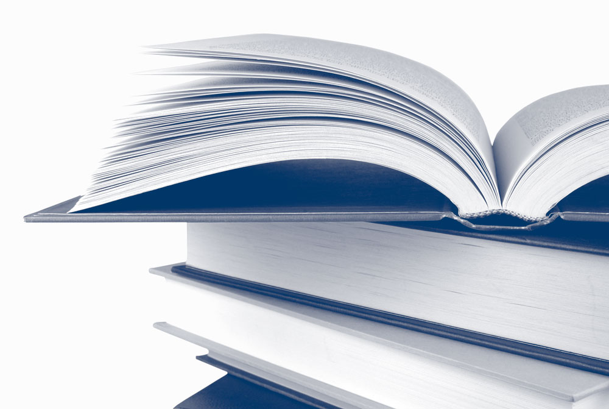

Source: [ICO Website](https://ico.org.uk/for-organisations/data-protection-act-2018/)

## Scenario 1

You successfully host a coffee and coding event with civil service colleagues. It seemed to go well but you would like to survey your attendees. You gain access to a Smart Survey license and spin up a questionnaire, seeking **anonymous** responses on the following:

- Attendees opinions on the coding tasks used.
- Which organisation the attendee represented.
- Diversity & Inclusion questions, such as race, gender & disability status.

## Response 1

Smart survey responses are pseudo-anonymised. IP addresses are one of the collected fields and could potentially be used to identify any given respondent.

It is crucial that the the necessary **fair usage notices** are included, ensuring compliance with duties under GDPR.

Collection of special category data such as that identified in the scenario are not currently collected. Collection of this data would require completion of a **D**ata **P**rotection **I**mpact **A**ssessment and risk assessment by the **D**ata **P**rotection **O**fficer prior to collection.

## Scenario 2

As a researcher, you have (legitimately) surveyed a large number of households and now have access to sensitive personal data. A colleague in a partner institution in Canada has shown an interest in your work and has requested a copy of your data on which they wish to base their research proposal.

Adapted from [St George’s University London](https://www.sgul.ac.uk/about/our-professional-services/information-services/information-governance/data-protection/data-protection-scenarios)

## Response 2

Unless you explicitly indicated your intention to share the data with this colleague/their institution when the data was originally obtained, you should not provide a copy to anyone else or use it for any other unrelated projects (**Limitation of purpose**). Data should only be used for the specified purpose(s) for which it was collected in the first place. If you intend to reanalyse the data for a separate but related project you should always inform the data subjects that you will be doing so.

You also need to be careful when transferring data to another country. Information can be sent to countries within the European Economic Area or EEA (the European Union plus Iceland, Lichtenstein and Norway). But it should only be sent outside the EEA if that territory offers adequate safeguards for the protection of the data. In the case of Canada it may only be sent to a company or organisation which has signed up to the ‘Safe Harbor’ agreement. A data transfer request would need to be pursued and the **I**nformation **C**ommissioner’s **O**ffice **DPO** should be made aware. Involvement of the **ICO** may be sought.

## Scenario 3

You have a show and tell session booked in with an external senior manager in the probation service. The project you’ve been developing uses personal data to predict offenders’ likelihood to re-offend within the next 5 years, with an astonishing accuracy of 90 %. You have diligently booked a meeting room for a remote conference call where you will be undisturbed. However, on starting the meeting, the manager is unable to connect and asks you to use an alternative browser-based conferencing service.

## Response 3

While pressured situations like this can lead to stress, you should be cautious of using unsupported conferencing software. Many widely-available conferencing solutions store their data on servers located outside of the EEC and some have recently been in the media for security breaches.

Use a supported alternative if available. If not, politely ask to reschedule the meeting until you are able to diagnose the cause of the connection issue or meet in person. Explain that sharing of sensitive information on unsupported platforms is against corporate guidance.

## Review Outcomes:

- Awareness of legislation affecting compliant collection, use and storage of personal data.
- Consideration of potential sanctions set out in legislation.
- Awareness of implications upon our day to day work.

## Helpful Resources

[Reggie GDPR guidance](https://intranet.ons.statistics.gov.uk/task/data-protection/undertaking-a-data-protection-impact-assessment/)

[ICO guidance on determining personal data](https://ico.org.uk/media/for-organisations/documents/1554/determining-what-is-personal-data.pdf)

[ONS data privacy notice](https://www.ons.gov.uk/aboutus/transparencyandgovernance/dataprotection#:~:text=It%20also%20includes%20genetic%20and,purposes%20based%20on%20UK%20law.%E2%80%9D)

UKSA Data Protection Officer Email: DPO@Statistics.gov.uk

## Thank you for your time

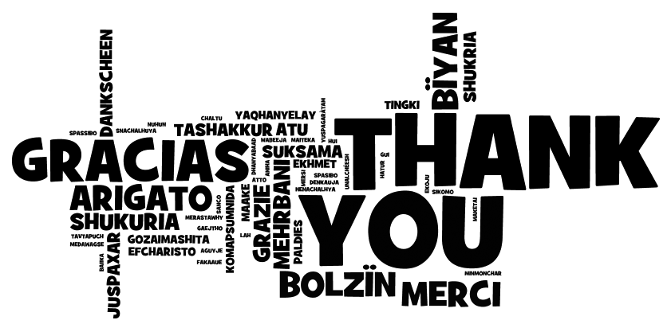

Source: [Wikimedia Commons](https://commons.wikimedia.org/wiki/File:Thank_you_in_many_languages,_b%26w.png)